# Ampliseq: check duplicates

Alexey Larionov

21 Dec 2021

# 1 Summary

6 samples failed sequencing because they had low call rates, clearly distinctive from the other samples (<60%):

- 108_S482_L008
- 152_S511_L008
- 306_S410_L008
- 346_S276_L008
- 384_S486_L008
- 498_S507_L008

Concordance rates were checked using common variants in each-to-each-case analysis for the remaining non-failed cases (see summary in **concordance_AL14Aug2018.xlsx**).

The purpose was to find the intentional duplicates introduced for QC purposes.

The concordance analysis detected 11 pairs of intended QC duplicates:

- 40_S189_L007 - 41_S328_L008
- 76_S299_L008 - 77_S370_L008
- 234_S381_L008 - 235_S535_L008
- 244_S175_L007 - 245_S59_L007
- 280_S173_L007 - 281_S185_L007 **both should be kept as explained by US collaborators**
- 347_S36_L007 - 348_S17_L007
- 398_S161_L007 - 399_S255_L007
- 436_S178_L007 - 437_S177_L007
- 517_S450_L008 - 518_S384_L008
- 527_S233_L007 - 528_S275_L008
- 539_S288_L008 - 540_S461_L008

The sample with lower coverage will be excluded fro analysis from each of the duplicated pairs.

One pair of intended duplicates was not detected because  
a sample from this pair failed sequencing (108):

- 108_S482_L008 - 109_S484_L008

The remaining sample 109 will be kept in the analysis.

Also, the concordance analysis detected one pair of additional duplicates (with distinct phenotypes):

- 270_S70_L007 - 351_S71_L007

These non-intended duplicates **are located near each other on the plate**, so it could be a lab mistake during dispensing/sequencing. **Both** of these samples will be excluded from analysis.

In the previous versions of analysis there was another pair of unexpected duplicates:

- 386_S273_L008 - 391_S376_L008

However, in Nov 2021 sample 391 was excluded from the analysis. So, sample 386 is now retained in the current version of analysis.

# 2 Start section

```r
# Time stamp
Sys.time()
```

```
## [1] "2021-12-21 17:27:51 GMT"
```

```r
# Clenan-up
rm(list=ls())
graphics.off()

# Memory
gc()
```

```
##          used (Mb) gc trigger (Mb) limit (Mb) max used (Mb)
## Ncells 433872 23.2     918942 49.1         NA   641382 34.3
## Vcells 831131  6.4    8388608 64.0      16384  1769098 13.5
```

```r
# Options
options(stringsAsFactors = F,
        warnPartialMatchArgs = T,
        warnPartialMatchAttr = T,
        warnPartialMatchDollar = T)

# Files and folders
base_folder="/Users/alexey/Documents/wecare/final_analysis_2021/reanalysis_afterNov2021/ampliseq/s01_ampliseq_wecare_only"
data_folder <- file.path(base_folder,"data","s04_select_samples")
#dir.create(data_folder)
scripts_folder <- file.path(base_folder,"scripts","s04_select_samples")
setwd(scripts_folder)
```

# 3 Read data

```r
# Load data
load(file.path(base_folder,"data","s03_read_data","s04_add_phenotypes.RData"))

# Update folders
base_folder="/Users/alexey/Documents/wecare/final_analysis_2021/reanalysis_afterNov2021/ampliseq/s01_ampliseq_wecare_only"
data_folder <- file.path(base_folder,"data","s04_select_samples")
scripts_folder <- file.path(base_folder,"scripts","s04_select_samples")
```

# 4 Check data

```r
ls()
```

```
##  [1] "ad.mx"          "alt.mx"         "base_folder"    "data_folder"    "dp.mx"          "gq.mx"          "gt_add.mx"      "gt_chr.mx"      "gt_num.mx"      "meta.df"        "phenotypes.df"  "ref.mx"         "scripts_folder" "variants.df"
```

```r
dim(gt_add.mx)
```

```
## [1] 13046   736
```

```r
dim(gt_num.mx)
```

```
## [1] 13046   736
```

```r
dim(gt_chr.mx)
```

```
## [1] 13046   736
```

```r
dim(ad.mx)
```

```
## [1] 13046   736
```

```r
dim(alt.mx)
```

```
## [1] 13046   736
```

```r
dim(ref.mx)
```

```
## [1] 13046   736
```

```r
dim(dp.mx)
```

```
## [1] 13046   736
```

```r
dim(gq.mx)
```

```
## [1] 13046   736
```

```r
dim(meta.df)
```

```
## [1] 129   5
```

```r
dim(phenotypes.df)
```

```
## [1] 736  25
```

```r
dim(variants.df)
```

```
## [1] 13046   138
```

```r
sum(rownames(gt_add.mx) != rownames(variants.df))
```

```
## [1] 0
```

```r
sum(colnames(gt_add.mx) != rownames(phenotypes.df))
```

```
## [1] 0
```

```r
write.table(phenotypes.df,
            file.path(data_folder, "s01_phenotypes.txt"),
            quote=F,row.names=F,sep="\t")
```

# 5 Check call rates

```r
call_rate.udf <- function(x)(1 - sum(is.na(x))/length(x))

samples_call_rate <- apply(gt_add.mx,2,call_rate.udf)

failed_samples <- samples_call_rate < 0.6

failed_samples_names <- colnames(gt_add.mx)[failed_samples]
failed_samples_names
```

```
## [1] "108_S482_L008" "152_S511_L008" "306_S410_L008" "346_S276_L008" "384_S486_L008" "498_S507_L008"
```

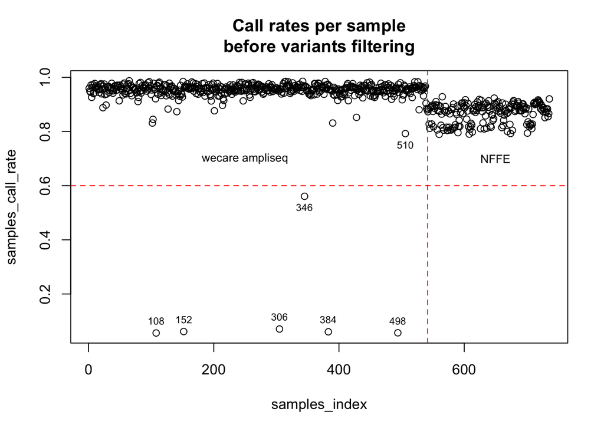

```r
plot(samples_call_rate, main="Call rates per sample\nbefore variants filtering", xlab="samples_index")
abline(h=0.6, lty=2, col="red")
abline(v=541.5, lty=2, col="red")

txt_lbl <- substr(colnames(gt_add.mx)[failed_samples],1,3)
txt_y <- samples_call_rate[failed_samples]
txt_x <- which(samples_call_rate < 0.6)
text(txt_x,txt_y,txt_lbl,cex=0.7,pos=c(3,3,3,1,3,3))

text(250,0.7,"wecare ampliseq",cex=0.8)
text(650,0.7,"NFFE",cex=0.8)

x510 <- which(phenotypes.df$Sample_num==510)
y510 <- samples_call_rate[x510]
text(x510,y510,"510",pos=1,cex=0.7)
```

```r
rm(txt_lbl,txt_x,txt_y,failed_samples,samples_call_rate,call_rate.udf,x510,y510)
```

# 6 Select wecare data

```r
# Select wecare
wecare_genotypes.mx <- gt_add.mx[,phenotypes.df$cc != -1]
dim(wecare_genotypes.mx)
```

```
## [1] 13046   538
```

```r
# Exclude failed samples
wecare_genotypes.mx <- wecare_genotypes.mx[,! colnames(wecare_genotypes.mx) %in% failed_samples_names]
dim(wecare_genotypes.mx)
```

```
## [1] 13046   532
```

```r
# Clean-up
rm(failed_samples_names)
```

# 7 Calculate concordance matrix

Use common variants in cases with call rate > 0.6

The chunk uses slow looping, but it takes < 1min and doesn’t need to be optimized because of the small data size

```r
# Calculate AF
wecare_af <- apply(wecare_genotypes.mx, 1, sum, na.rm=T)/(ncol(wecare_genotypes.mx)*2)
length(wecare_af)
```

```
## [1] 13046
```

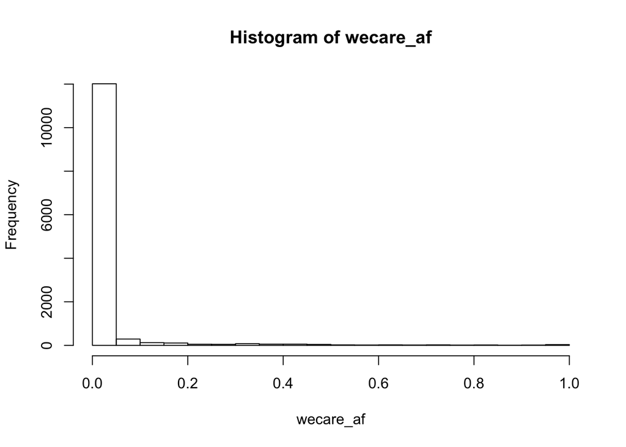

```r
hist(wecare_af)
```

```r
# Select common variants
common_vars <- wecare_af >= 0.05 & wecare_af <= 0.95
sum(common_vars)
```

```
## [1] 997
```

```r
gt_com.mx <- wecare_genotypes.mx[common_vars,]
dim(gt_com.mx)
```

```
## [1] 997 532
```

```r
# Initialize the concordance matrix
cnc.mx <- matrix(NA, ncol=ncol(gt_com.mx), nrow=ncol(gt_com.mx))
colnames(cnc.mx) <- colnames(gt_com.mx)
rownames(cnc.mx) <- colnames(gt_com.mx)
cnc.mx[1:5,1:5]
```

```
##             1_S441_L008 2_S134_L007 3_S360_L008 4_S66_L007 5_S395_L008
## 1_S441_L008          NA          NA          NA         NA          NA
## 2_S134_L007          NA          NA          NA         NA          NA
## 3_S360_L008          NA          NA          NA         NA          NA
## 4_S66_L007           NA          NA          NA         NA          NA
## 5_S395_L008          NA          NA          NA         NA          NA
```

```r
# Initialize counts matrix
cnt.mx <- matrix(NA, ncol=ncol(gt_com.mx), nrow=ncol(gt_com.mx))
colnames(cnt.mx) <- colnames(gt_com.mx)
rownames(cnt.mx) <- colnames(gt_com.mx)
cnt.mx[1:5,1:5]
```

```
##             1_S441_L008 2_S134_L007 3_S360_L008 4_S66_L007 5_S395_L008
## 1_S441_L008          NA          NA          NA         NA          NA
## 2_S134_L007          NA          NA          NA         NA          NA
## 3_S360_L008          NA          NA          NA         NA          NA
## 4_S66_L007           NA          NA          NA         NA          NA
## 5_S395_L008          NA          NA          NA         NA          NA
```

```r
# Calculate concordances
for(sample_1 in colnames(gt_com.mx)){
  for(sample_2 in colnames(gt_com.mx)){

    # Get vectors of variants for both samples
    smp1 <- gt_com.mx[,sample_1]
    smp2 <- gt_com.mx[,sample_2]

    # Calculate concordance
    total <- sum(!is.na(smp1) & !is.na(smp2))
    concordant <- sum(smp1==smp2, na.rm=T)
    concordance_rate <- concordant / total

    # Write result
    if(sample_1 == sample_2){
      NA  -> cnt.mx[sample_1,sample_2]
      NA  -> cnc.mx[sample_1,sample_2]
    }else{
      total -> cnt.mx[sample_1,sample_2]
      concordance_rate -> cnc.mx[sample_1,sample_2]
    }
  }
}

# Check results
cnt.mx[1:5,1:5]
```

```
##             1_S441_L008 2_S134_L007 3_S360_L008 4_S66_L007 5_S395_L008
## 1_S441_L008          NA         958         954        972         939
## 2_S134_L007         958          NA         946        961         933
## 3_S360_L008         954         946          NA        957         930
## 4_S66_L007          972         961         957         NA         942
## 5_S395_L008         939         933         930        942          NA
```

```r
cnc.mx[1:5,1:5]
```

```
##             1_S441_L008 2_S134_L007 3_S360_L008 4_S66_L007 5_S395_L008
## 1_S441_L008          NA   0.5960334   0.5744235  0.5421811   0.6155485
## 2_S134_L007   0.5960334          NA   0.5750529  0.5660770   0.6045016
## 3_S360_L008   0.5744235   0.5750529          NA  0.5684431   0.5623656
## 4_S66_L007    0.5421811   0.5660770   0.5684431         NA   0.5180467
## 5_S395_L008   0.6155485   0.6045016   0.5623656  0.5180467          NA
```

```r
write.table(cnc.mx,
            file.path(data_folder, "s01_conc_matrix.txt"),
            quote=F,sep="\t")

# Clean-up
rm(common_vars, gt_com.mx, sample_1, sample_2, smp1, smp2,
   total, concordant, concordance_rate, wecare_af)
```

# 8 Explore concordance matrix

```r
# No missed values (except self-concordance/count)
dim(cnt.mx)
```

```
## [1] 532 532
```

```r
sum(is.na(cnt.mx))
```

```
## [1] 532
```

```r
sum(is.na(cnc.mx))
```

```
## [1] 532
```

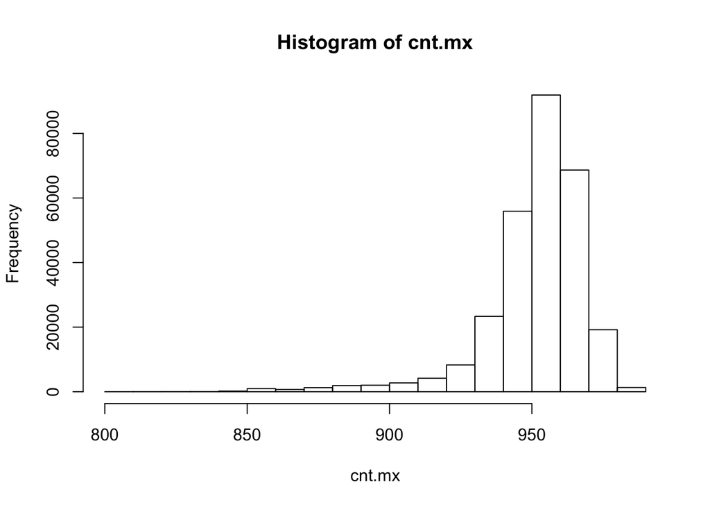

```r
# Histograms

hist(cnt.mx)
```

```r
quantile(cnt.mx, na.rm=T)
```

```
##   0%  25%  50%  75% 100%
##  806  946  955  963  990
```

```r
mean(cnt.mx, na.rm=T)
```

```
## [1] 951.9484
```

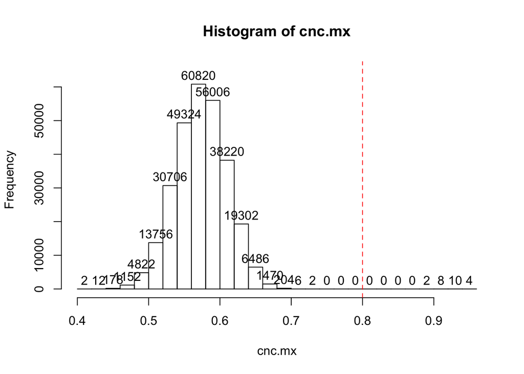

```r
hist(cnc.mx, ylim=c(0,65000), lab=T)
abline(v=0.8,lty=2,col="red")
```

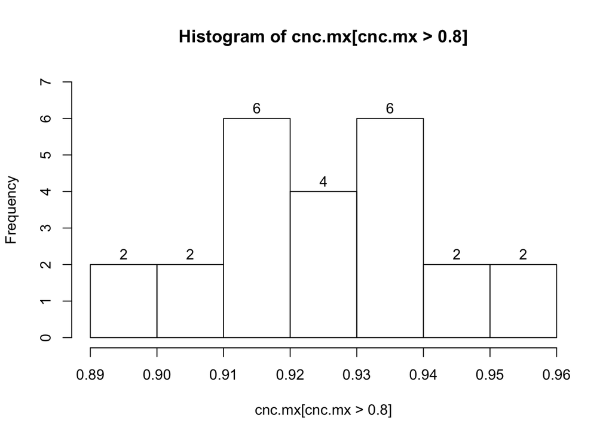

```r
hist(cnc.mx[cnc.mx > 0.8], lab=T, ylim=c(0,7))
```

```r
sum(cnc.mx > 0.85, na.rm=T)
```

```
## [1] 24
```

```r
sum(cnc.mx == 1, na.rm=T)
```

```
## [1] 0
```

```r
# Make list of most similar samples (concordance > 0.94)
conc_cases.mx <- matrix(nrow=0, ncol=4)
c("sample_1","sample_2","count","concordance") -> colnames(conc_cases.mx)
for(sample_1 in rownames(cnc.mx)){
  for(sample_2 in colnames(cnc.mx)){
    if(sample_1!=sample_2 & cnc.mx[sample_1,sample_2] > 0.8 ){
      conc_cases.mx <- rbind(conc_cases.mx, c(sample_1,sample_2,
                                              cnt.mx[sample_1,sample_2],
                                              cnc.mx[sample_1,sample_2]))
    }
  }
}

# Check result
conc_cases.mx
```

```
##       sample_1        sample_2        count concordance
##  [1,] "40_S189_L007"  "41_S328_L008"  "951" "0.890641430073607"
##  [2,] "41_S328_L008"  "40_S189_L007"  "951" "0.890641430073607"
##  [3,] "76_S299_L008"  "77_S370_L008"  "951" "0.907465825446898"
##  [4,] "77_S370_L008"  "76_S299_L008"  "951" "0.907465825446898"
##  [5,] "234_S381_L008" "235_S535_L008" "960" "0.930208333333333"
##  [6,] "235_S535_L008" "234_S381_L008" "960" "0.930208333333333"
##  [7,] "244_S175_L007" "245_S59_L007"  "966" "0.915113871635611"
##  [8,] "245_S59_L007"  "244_S175_L007" "966" "0.915113871635611"
##  [9,] "270_S70_L007"  "351_S71_L007"  "975" "0.928205128205128"
## [10,] "280_S173_L007" "281_S185_L007" "942" "0.945859872611465"
## [11,] "281_S185_L007" "280_S173_L007" "942" "0.945859872611465"
## [12,] "347_S36_L007"  "348_S17_L007"  "975" "0.922051282051282"
## [13,] "348_S17_L007"  "347_S36_L007"  "975" "0.922051282051282"
## [14,] "351_S71_L007"  "270_S70_L007"  "975" "0.928205128205128"
## [15,] "398_S161_L007" "399_S255_L007" "951" "0.950578338590957"
## [16,] "399_S255_L007" "398_S161_L007" "951" "0.950578338590957"
## [17,] "436_S178_L007" "437_S177_L007" "944" "0.932203389830508"
## [18,] "437_S177_L007" "436_S178_L007" "944" "0.932203389830508"
## [19,] "517_S450_L008" "518_S384_L008" "954" "0.930817610062893"
## [20,] "518_S384_L008" "517_S450_L008" "954" "0.930817610062893"
## [21,] "527_S233_L007" "528_S275_L008" "962" "0.914760914760915"
## [22,] "528_S275_L008" "527_S233_L007" "962" "0.914760914760915"
## [23,] "539_S288_L008" "540_S461_L008" "946" "0.915433403805497"
## [24,] "540_S461_L008" "539_S288_L008" "946" "0.915433403805497"
```

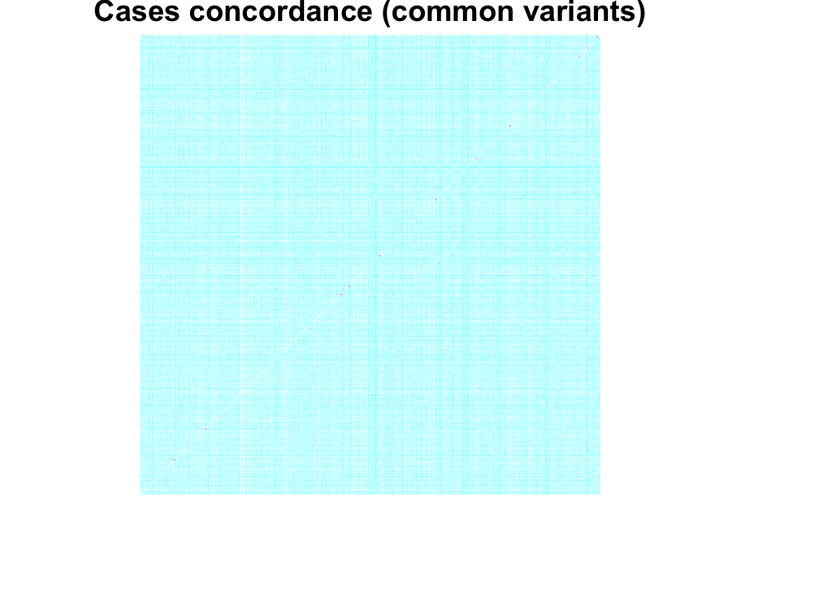

```r
write.table(conc_cases.mx,
            file.path(data_folder, "s01_conc_cases.txt"),
            quote=F,row.names=F,sep="\t")

# Heatmaps
heatmap(cnc.mx, Rowv=NA, Colv=NA, scale='none',
        col = cm.colors(256), labRow=NA, labCol = NA,
        main="Cases concordance (common variants)")
```

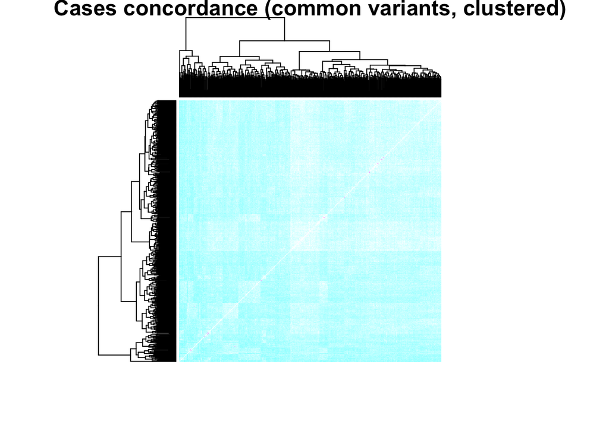

```r
heatmap(cnc.mx, scale='none',
        col = cm.colors(256), labRow=NA, labCol = NA,
        main="Cases concordance (common variants, clustered)")
```

```r
# Clean-up
rm(sample_1, sample_2)
```

# 9 Check phenotypes annotations in concordant cases

## 9.1 Expected duplicates

Phenotype records for expected duplicates are identical,  
except for one case, which is intentionally used twice in different capacities  
(once as case and once as control)

```r
dim(phenotypes.df)
```

```
## [1] 736  25
```

```r
colnames(phenotypes.df)
```

```
##  [1] "long_ids"         "illumina_id"      "illumina_lane"    "Sample_num"       "cc"               "rstime"           "sub_dx_age"       "hormone_self_mra" "chemo_self_mra"   "treatment"        "Hist_lob_other"   "stage_fd"         "histo1_cat"       "er1_cat"          "pr1_cat"          "grade1…
```

```r
x <- phenotypes.df["40_S189_L007",] != phenotypes.df["41_S328_L008",]
sum(x[5:24]) # exclude long_ids illumina_id illumina_lane Sample_num fields
```

```
## [1] 0
```

```r
x <- phenotypes.df["76_S299_L008",] != phenotypes.df["77_S370_L008",]
sum(x[5:24]) # exclude long_ids illumina_id illumina_lane Sample_num fields
```

```
## [1] 0
```

```r
x <- phenotypes.df["234_S381_L008",] != phenotypes.df["235_S535_L008",]
sum(x[5:24]) # exclude long_ids illumina_id illumina_lane Sample_num fields
```

```
## [1] 0
```

```r
x <- phenotypes.df["244_S175_L007",] != phenotypes.df["245_S59_L007",]
sum(x[5:24]) # exclude long_ids illumina_id illumina_lane Sample_num fields
```

```
## [1] 0
```

```r
x <- phenotypes.df["280_S173_L007",] != phenotypes.df["281_S185_L007",]
sum(x[5:24]) # exclude long_ids illumina_id illumina_lane Sample_num fields
```

```
## [1] 3
```

```r
phenotypes.df[c("280_S173_L007","281_S185_L007"),x]
```

```
##                    long_ids illumina_id Sample_num cc rstime  setno
## 280_S173_L007 280_S173_L007        S173        280  0   5.92 269688
## 281_S185_L007 281_S185_L007        S185        281  1   7.33 342191
```

```r
# cc and rstime differ because used in different capacity for different pairs
# **both samples should be kept in analysis**

x <- phenotypes.df["347_S36_L007",] != phenotypes.df["348_S17_L007",]
sum(x[5:24]) # exclude long_ids illumina_id illumina_lane Sample_num fields
```

```
## [1] 0
```

```r
x <- phenotypes.df["398_S161_L007",] != phenotypes.df["399_S255_L007",]
sum(x[5:24]) # exclude long_ids illumina_id illumina_lane Sample_num fields
```

```
## [1] 0
```

```r
x <- phenotypes.df["436_S178_L007",] != phenotypes.df["437_S177_L007",]
sum(x[5:24]) # exclude long_ids illumina_id illumina_lane Sample_num fields
```

```
## [1] 0
```

```r
x <- phenotypes.df["517_S450_L008",] != phenotypes.df["518_S384_L008",]
sum(x[5:24]) # exclude long_ids illumina_id illumina_lane Sample_num fields
```

```
## [1] 0
```

```r
x <- phenotypes.df["527_S233_L007",] != phenotypes.df["528_S275_L008",]
sum(x[5:24]) # exclude long_ids illumina_id illumina_lane Sample_num fields
```

```
## [1] 0
```

```r
x <- phenotypes.df["539_S288_L008",] != phenotypes.df["540_S461_L008",]
sum(x[5:24]) # exclude long_ids illumina_id illumina_lane Sample_num fields
```

```
## [1] 0
```

## 9.2 Unexpected duplicates

```r
x <- phenotypes.df["270_S70_L007",] != phenotypes.df["351_S71_L007",]
sum(x[5:21]) # exclude long_ids illumina_id illumina_lane Sample_num fields
```

```
## [1] 6
```

```r
phenotypes.df[c("270_S70_L007","351_S71_L007"),x]
```

```
##                  long_ids illumina_id Sample_num cc rstime sub_dx_age  pr1_cat Num_ftp_fd num_ftp_rd  setno xrtbreast
## 270_S70_L007 270_S70_L007         S70        270  1   5.00         50 negative          4          4 230845         0
## 351_S71_L007 351_S71_L007         S71        351  0   4.08         53 positive          2          2 217302         1
```

```r
rm(x)
```

# 10 Final section

```r
ls()
```

```
##  [1] "ad.mx"               "alt.mx"              "base_folder"         "cnc.mx"              "cnt.mx"              "conc_cases.mx"       "data_folder"         "dp.mx"               "gq.mx"               "gt_add.mx"           "gt_chr.mx"           "gt_num.mx"           "meta.df"             "pheno…
```

```r
Sys.time()
```

```
## [1] "2021-12-21 17:28:30 GMT"
```

```r
gc()
```

```
##            used  (Mb) gc trigger  (Mb) limit (Mb)  max used  (Mb)
## Ncells   766272  41.0    1733531  92.6         NA   1733531  92.6
## Vcells 78074009 595.7  117903362 899.6      16384 117903333 899.6
```